# Scienza sotto pressione

AI in sanità e disinformazione medica, spiegate ai giornalisti

Matteo Baraggini

2026-07-09

Sommario

Numero prototipale di “Scienza sotto pressione”, newsletter che raccoglie e sintetizza ricerche scientifiche recenti, pubblicate con licenza open access, su intelligenza artificiale in sanità e disinformazione medica, rivolta a giornalisti, operatori dell’informazione e comunicatori scientifici.

# Introduzione

Viviamo in un’epoca in cui due forze tecnologiche e sociali stanno ridisegnando il modo in cui produciamo, consumiamo e valutiamo l’informazione. Da un lato, l’intelligenza artificiale avanza a una velocità senza precedenti, penetrando settori cruciali come la medicina, il diritto e l’istruzione. Dall’altro, la disinformazione si diffonde con altrettanta rapidità attraverso le piattaforme digitali, minando la fiducia pubblica nella scienza e nelle istituzioni. Due fenomeni distinti, ma sempre più intrecciati.

Per i giornalisti e i comunicatori scientifici, capire queste dinamiche non è solo una questione di aggiornamento professionale: è una necessità. L’AI sta già cambiando le pratiche redazionali, la verifica dei fatti e la produzione di contenuti. La disinformazione, nel frattempo, non riguarda solo la politica — come dimostrano anni di infodemia sanitaria, dal COVID-19 ai vaccini — ma investe direttamente il rapporto tra cittadini e conoscenza scientifica.

Questa newsletter raccoglie e sintetizza ricerche scientifiche recenti, pubblicate con licenza open access, su entrambi i fronti. L’obiettivo non è fornire risposte definitive, ma offrire strumenti affidabili per orientarsi in un panorama informativo sempre più complesso. Ogni sintesi è accompagnata dal link diretto alla fonte originale, per chi vuole approfondire.

## I numeri di questo numero

Due grafici per orientarsi prima di leggere: quanto sta crescendo la ricerca sull’AI in sanità, e quanto sono ampi gli studi che abbiamo selezionato per questo numero.

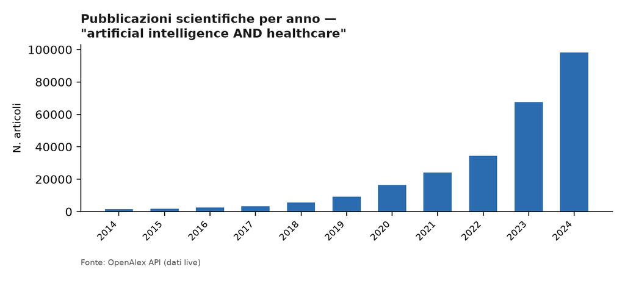

Crescita della produzione scientifica su AI in sanità, 2014–2024.

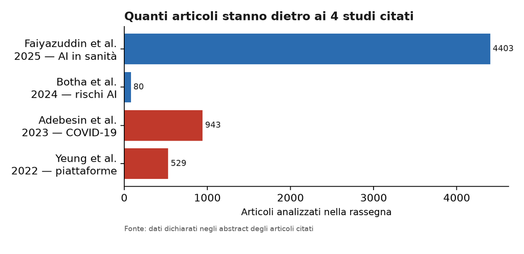

Quanti articoli stanno dietro alle quattro rassegne citate in questo numero.

## Sezione 1: Intelligenza Artificiale

### Introduzione

L’intelligenza artificiale è entrata negli ospedali, negli ambulatori e nei sistemi di diagnosi senza che la maggior parte dei pazienti se ne accorgesse. Algoritmi di machine learning analizzano referti radiologici, modelli predittivi stimano il rischio di ricovero, chatbot rispondono a domande cliniche. Una trasformazione profonda, che promette di rendere la medicina più precisa, più rapida e più accessibile — ma che porta con sé interrogativi etici e pratici ancora irrisolti.

La ricerca scientifica degli ultimi anni ha iniziato a fare i conti con questa realtà in modo sistematico. Da un lato emerge un quadro di potenziale straordinario: l’AI migliora le capacità diagnostiche dei medici, apre la strada a trattamenti personalizzati e ottimizza l’efficienza operativa delle strutture sanitarie. Dall’altro, gli stessi studi segnalano rischi concreti — bias nei dati di addestramento, opacità degli algoritmi, vulnerabilità nella gestione dei dati sensibili — che possono tradursi in discriminazioni o violazioni dei diritti dei pazienti.

### Articolo 2 — AI in sanità: i rischi per i diritti e la sicurezza dei pazienti

Se il potenziale dell’AI in medicina è indubbio, i rischi per i pazienti restano ancora sottovalutati. Una scoping review pubblicata su *Archives of Public Health* ha analizzato 80 articoli peer-reviewed pubblicati tra il 2010 e il 2023, mappando le minacce percepite all’uso degli strumenti AI nella cura della salute. I risultati sono preoccupanti: gli autori documentano la possibilità concreta di errori imprevedibili degli algoritmi, l’assenza di un quadro regolatorio adeguato, e il rischio di bias e discriminazioni nei sistemi automatizzati di diagnosi e raccomandazione terapeutica. A questi si aggiungono problemi di privacy dei dati clinici, aumento dei costi sanitari e una progressiva riduzione dell’autonomia del paziente nel processo di cura — quello che gli autori chiamano “paternalismo medico digitale”. Lo studio raccomanda ai governi nazionali di assumere un ruolo guida nella regolamentazione dell’AI sanitaria, in linea con gli obiettivi di sviluppo sostenibile dell’ONU.

**Open access.** *Fonte: Botha et al., Archives of Public Health, 2024 — [testo completo su PMC](https://pmc.ncbi.nlm.nih.gov/articles/PMC11515716/)*

## Sezione 2: Disinformazione

### Introduzione

Nell’era dei social media, la disinformazione non è più solo un problema politico o culturale — è diventata una questione di salute pubblica. Durante la pandemia di COVID-19 il mondo ha fatto i conti con quella che l’OMS ha definito “infodemia”: una sovrabbondanza di informazioni, vere e false, che si diffondono più velocemente del virus stesso. Vaccini, terapie non provate, teorie del complotto — sui social media tutto ha circolato alla stessa velocità, con effetti misurabili sulla compliance alle misure sanitarie e sulla fiducia nelle istituzioni.

Ma il fenomeno non nasce con il COVID-19 e non si esaurisce con esso. La misinformazione medica online ha radici più profonde e un perimetro molto più ampio: riguarda l’alimentazione, i farmaci, la salute mentale, i movimenti no-vax. La comunità scientifica ha risposto con un crescente corpo di ricerca dedicato a capire come si diffondono le notizie false in ambito sanitario, quali piattaforme le amplificano di più e quali strumenti possono arginarle.

Per i giornalisti scientifici, conoscere questo panorama è essenziale. I due studi che seguono offrono due prospettive complementari: il primo analizza specificamente il ruolo dei social media nella disinformazione sanitaria durante la pandemia, il secondo allarga lo sguardo all’intera letteratura scientifica sul tema, identificando tendenze, piattaforme e lacune della ricerca.

### Articolo 3 — COVID-19 e social media: come la pandemia ha accelerato la ricerca sulla disinformazione sanitaria

La pandemia di COVID-19 ha trasformato i social media in un laboratorio involontario per lo studio della disinformazione sanitaria. Una analisi bibliometrica pubblicata su *JMIR Infodemiology* ha esaminato 943 articoli scientifici pubblicati tra il 2020 e il 2023, mappando l’evoluzione della ricerca sul ruolo dei social media nella diffusione di misinformazione e disinformazione in ambito sanitario. I risultati mostrano un’esplosione della produzione scientifica nel 2022, con 387 pubblicazioni, pari al 41% del totale analizzato. Le parole chiave più ricorrenti — COVID-19, social media, misinformation — riflettono la centralità della pandemia come evento scatenante. Un dato interessante emerge però guardando ai temi di nicchia: algoritmi di machine learning e sistemi di apprendimento automatico si profilano come i principali strumenti futuri per rilevare e contrastare la disinformazione online. La ricerca in questo campo è ancora giovane, ma cresce rapidamente — e con essa la consapevolezza che le emergenze sanitarie globali sono anche emergenze informative.

**Open access.** *Fonte: Adebesin et al., JMIR Infodemiology, 2023 — [testo completo su PMC](https://pmc.ncbi.nlm.nih.gov/articles/PMC10551800/)*

### Articolo 4 — Misinformazione medica online: Twitter, YouTube e Facebook sotto la lente della scienza

Quali piattaforme social amplificano di più la disinformazione medica? Una analisi bibliometrica pubblicata sul *Journal of Medical Internet Research* ha studiato 529 articoli scientifici per rispondere a questa domanda. I risultati mostrano che Twitter, YouTube e Facebook sono le piattaforme più studiate — e anche quelle con il maggiore impatto in termini di citazioni scientifiche. Non è però solo una questione di quantità: ogni piattaforma tende ad amplificare tipi diversi di disinformazione. Twitter è associato principalmente a ipocondria e cyberchondria, YouTube alla disinformazione sul fumo, Facebook alla vaccine hesitancy legata all’autismo. Il COVID-19 è l’unico tema trasversale a tutte le piattaforme. Un limite rilevante emerge dai dati: l’80% degli studi proviene da istituzioni statunitensi, lasciando scoperte piattaforme molto diffuse fuori dall’Occidente come WeChat, Weibo e TikTok — un gap che la ricerca futura dovrà colmare per avere una visione davvero globale del fenomeno.

**Open access.** *Fonte: Yeung et al., Journal of Medical Internet Research, 2022 — [testo completo su PMC](https://pmc.ncbi.nlm.nih.gov/articles/PMC8793917/)*